# Machine Learning Algorithm Tuning with mlr3

# Intro

In this case we will continue working with the **German Credit Dataset**. Yesterday we peeked into the data set by using and comparing some learners with ther default parameters. We will now see how to:

- Tune hyperparameters for a given problem
- Perform nested resampling
- Adjust decision thresholds

# Prerequisites

We expect you have installed all packages from day 1. If not, load the day 1 script and run the **Prerequisites** install chunk.

Load the packages we are going to use:

```r
library("data.table")
library("magrittr")
library("mlr3")
library("mlr3learners")
library("ggplot2")
theme_set(theme_light())
```

We use the same data as yesterday.

```r
# load the data set (id 31) from OpenML Library, clean it up and convert it
# to a TaskClassif.
task = mlr3misc::encapsulate("callr", function() {
  data.table::as.data.table(OpenML::getOMLDataSet(data.id = 31))
}) %$% droplevels(result) %>%
  TaskClassif$new(id = "new_credit", target = "class", positive = "good")
```

Also, because tuning often takes a long time, we want to make more efficient use of our multicore CPUs.

```r
future::plan("multiprocess")
```

## Evaluation

We evaluate all algorithms using 10-fold cross-validation. We use a *fixed* train-test split, i.e. the same splits for each evaluation. Otherwise, some evaluation could get unusually “hard” splits, which would make comparisons unfair.

```r
set.seed(8008135)
cv10_instance = rsmp("cv", folds = 10)$instantiate(task)
```

# Simple Parameter Tuning

- Use the `paradox` package for search space definition
- Use the `mlr3tuning` package for tuning

```r
library("mlr3tuning")
library("paradox")
```

## Search Space and Prolem Definition

- First need to decide what `Learner` to optimize.
  - (We could also try to optimize multiple `Learner`s simultaneously, i.e. choose the `Learner` to use automatically. We get to that in Day 3)
  - We use `"classif.kknn"`, the “kernelized” k-nearest neighbour classifier
- Then we decide what parameters we optimize over
  - What are our options?

```r
knn = lrn("classif.kknn", predict_type = "prob")
print(knn$param_set)
```

```
#> ParamSet:
#>          id    class lower upper                                                         levels default value
#> 1:        k ParamInt     1   Inf                                                                      7
#> 2: distance ParamDbl     0   Inf                                                                      2
#> 3:   kernel ParamFct    NA    NA rectangular,triangular,epanechnikov,biweight,triweight,cos,... optimal
#> 4:    scale ParamLgl    NA    NA                                                     TRUE,FALSE    TRUE
```

- We will use `kknn` as a normal kNN without weighting first:

```r
knn$param_set$values$kernel = "rectangular"
```

```r
searchspace = ParamSet$new(list(
  ParamInt$new("k", lower = 3, upper = 20),
  ParamInt$new("distance", lower = 1, upper = 2)
))
```

- We define a “tuning instance” that represents the problem we are trying to optimize.
  - What is the task we are optimizing for?
  - What learner are we using?
  - How do we do resampling?
  - What is the performance measure?
  - What is the search space (“parameter set”)?
  - When are we done searching? (Disregard this for now).

```r
instance_grid = TuningInstance$new(
  task = task,
  learner = knn,
  resampling = cv10_instance,
  measures = msr("classif.ce"),
  param_set = searchspace,
  terminator = term("none")
)
```

## Grid Search

- A simple tuning method is to try all possible combinations of parameters: **Grid Search**
  - Pro: Very intuitive and simple
  - Con: Inefficient if the search space is large
- We get the `"grid_search"` tuner for this

```r
tuner_grid = tnr("grid_search", resolution = 18, batch_size = 36)
```

```r
tuner_grid$tune(instance_grid)
```

- The result can be found in the `$result` slot. We can also plot the performance.

```r
instance_grid$result
```

```
#> $tune_x
#> $tune_x$k
#> [1] 6
#>
#> $tune_x$distance
#> [1] 2
#>
#>
#> $params
#> $params$kernel
#> [1] "rectangular"
#>
#> $params$k
#> [1] 6
#>
#> $params$distance
#> [1] 2
#>
#>
#> $perf
#> classif.ce
#>      0.248
```

- We can look at the “archive” of evaluated configurations
- We expand the “params” (the parameters that the `Learner` actually saw)

```r
perfdata = instance_grid$archive("params")
perfdata[, .(nr, k, distance, classif.ce)]
```

```
#>     nr  k distance classif.ce
#>  1:  1  3        1      0.275
#>  2:  2  3        2      0.271
#>  3:  3  4        1      0.275
#>  4:  4  4        2      0.271
#>  5:  5  5        1      0.266
#>  6:  6  5        2      0.248
#>  7:  7  6        1      0.266
#>  8:  8  6        2      0.248
#>  9:  9  7        1      0.258
#> 10: 10  7        2      0.249
#> 11: 11  8        1      0.258
#> 12: 12  8        2      0.249
#> 13: 13  9        1      0.259
#> 14: 14  9        2      0.249
```

[output cut: 23 more lines]

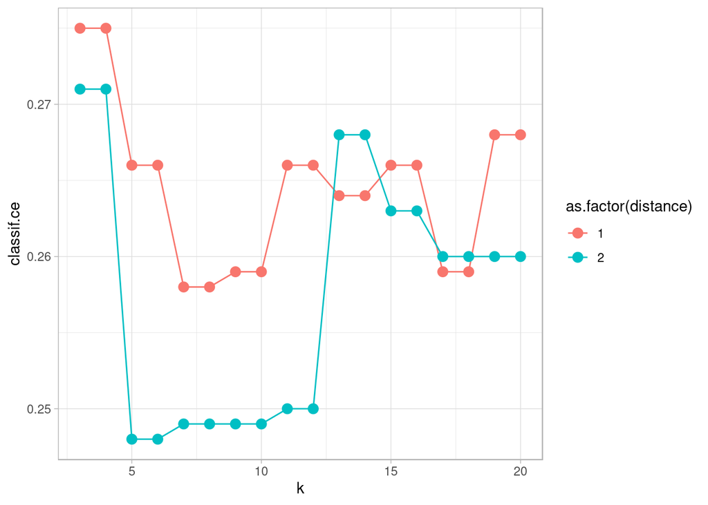

```r
ggplot(perfdata, aes(x = k, y = classif.ce, color = as.factor(distance))) +
  geom_line() + geom_point(size = 3)
```

- Euclidean distance (`distance` = 2) seems to work better, but there is much randomness introduced by the resampling instance, so you may see a different result!
- `k` between 5 and 10 perform well

## Random Search and Transformation

- Let’s look at a larger search space. In fact, how about we tune *all* available parameters and limit `k` to large values (50).
- **Problem 1**: The difference between `k` = 3 and `k` = 4 is probably larger than the difference between `k` = 49 and `k` = 50.
  - We will use a **transformation function** and sample on the log-space.
  - For this we define the range for `k` from `log(3)` to `log(50)` and exponentiate in the transformation.
    - We must use `ParamDbl` instead of `ParamInt` now!

```r
large_searchspace = ParamSet$new(list(
  ParamDbl$new("k", lower = log(3), upper = log(50)),
  ParamDbl$new("distance", lower = 1, upper = 3),
  ParamFct$new("kernel", c("rectangular", "gaussian", "rank", "optimal")),
  ParamLgl$new("scale")
))

large_searchspace$trafo = function(x, param_set) {
  x$k = round(exp(x$k))
  x
}
```

- **Problem 2**: Using grid search will take a long time.
  - Even trying out three different values for `k`, `distance`, `kernel` and the two values for `scale` will take 54 evaluations.
  - We use a different search algorithm: **Random Search**
  - The *tuning instance* must now contain a *termination criterion*: When do we stop?

```r
tuner_random = tnr("random_search", batch_size = 36)

instance_random = TuningInstance$new(
  task = task,
  learner = knn,
  resampling = cv10_instance,
  measures = msr("classif.ce"),
  param_set = large_searchspace,
  terminator = term("evals", n_evals = 36)
)
```

```r
tuner_random$tune(instance_random)
```

- We can get the “archive” in two ways: expand the `"tune_x"` parameters (the points we sampled on the search space), and the `"params"` parameters: the points the `Learner` was used with—these are the `exp()`’d parameters!

```r
perfdata = instance_random$archive("tune_x")
perfdata[, .(k, distance, kernel, scale, classif.ce)]
```

```
#>            k distance      kernel scale classif.ce
#>  1: 3.511106 2.635749    gaussian FALSE      0.297
#>  2: 3.137481 1.648984 rectangular  TRUE      0.270
#>  3: 2.773994 1.913277     optimal FALSE      0.322
#>  4: 2.708423 2.205144     optimal  TRUE      0.250
#>  5: 2.200522 2.528389        rank  TRUE      0.259
#>  6: 1.192254 1.146768    gaussian FALSE      0.363
#>  7: 2.522298 1.440319    gaussian  TRUE      0.244
#>  8: 1.455438 2.066815        rank  TRUE      0.273
#>  9: 1.332023 1.057991    gaussian  TRUE      0.277
#> 10: 3.183821 1.025020    gaussian  TRUE      0.261
#> 11: 1.416903 1.875307    gaussian  TRUE      0.273
#> 12: 3.149992 1.218274     optimal  TRUE      0.246
#> 13: 3.880114 1.097063 rectangular FALSE      0.294
#> 14: 1.956195 1.052008    gaussian  TRUE      0.257
```

[output cut: 23 more lines]

```r
perfdata = instance_random$archive("params")
perfdata[, .(k, distance, kernel, scale, classif.ce)]
```

```
#>      k distance      kernel scale classif.ce
#>  1: 33 2.635749    gaussian FALSE      0.297
#>  2: 23 1.648984 rectangular  TRUE      0.270
#>  3: 16 1.913277     optimal FALSE      0.322
#>  4: 15 2.205144     optimal  TRUE      0.250
#>  5:  9 2.528389        rank  TRUE      0.259
#>  6:  3 1.146768    gaussian FALSE      0.363
#>  7: 12 1.440319    gaussian  TRUE      0.244
#>  8:  4 2.066815        rank  TRUE      0.273
#>  9:  4 1.057991    gaussian  TRUE      0.277
#> 10: 24 1.025020    gaussian  TRUE      0.261
#> 11:  4 1.875307    gaussian  TRUE      0.273
#> 12: 23 1.218274     optimal  TRUE      0.246
#> 13: 48 1.097063 rectangular FALSE      0.294
#> 14:  7 1.052008    gaussian  TRUE      0.257
```

[output cut: 23 more lines]

Let’s look at some plots of performance by parameter. - the following suggests that `scale` has a strong influence on performance.

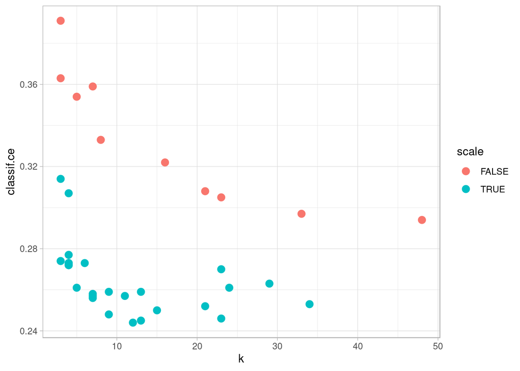

```r
ggplot(perfdata, aes(x = k, y = classif.ce, color = scale)) +
  geom_point(size = 3)
```

- The kernel seems to be less influential:

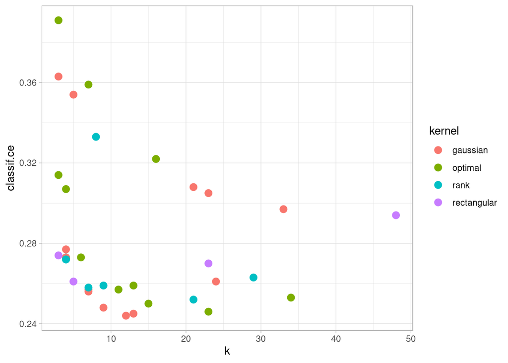

```r
ggplot(perfdata, aes(x = k, y = classif.ce, color = kernel)) +
  geom_point(size = 3)
```

- The influence of `distance` seems to be negligible

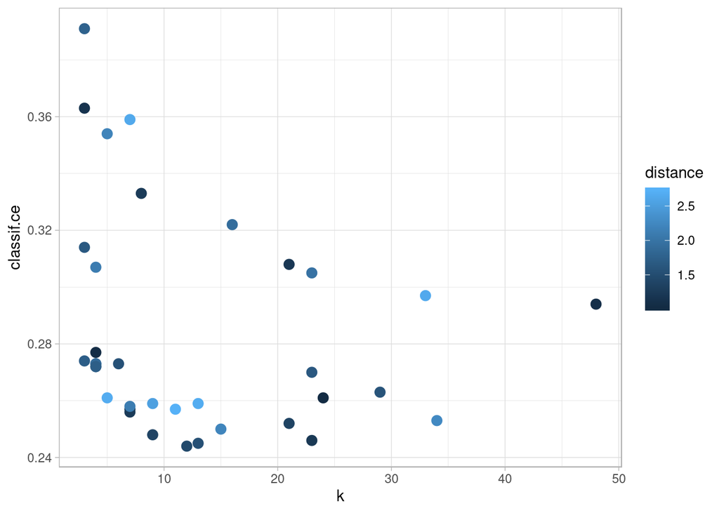

```r
ggplot(perfdata, aes(x = k, y = classif.ce, color = distance)) +
  geom_point(size = 3)
```

It is always interesting to look at what could have been. The following dataset contains an optimization run result with 3600 evaluations–more than above by a factor of 100.

```r
perfdata = readRDS("randomsearch_3600.rds")
```

- The scale effect is just as visible.

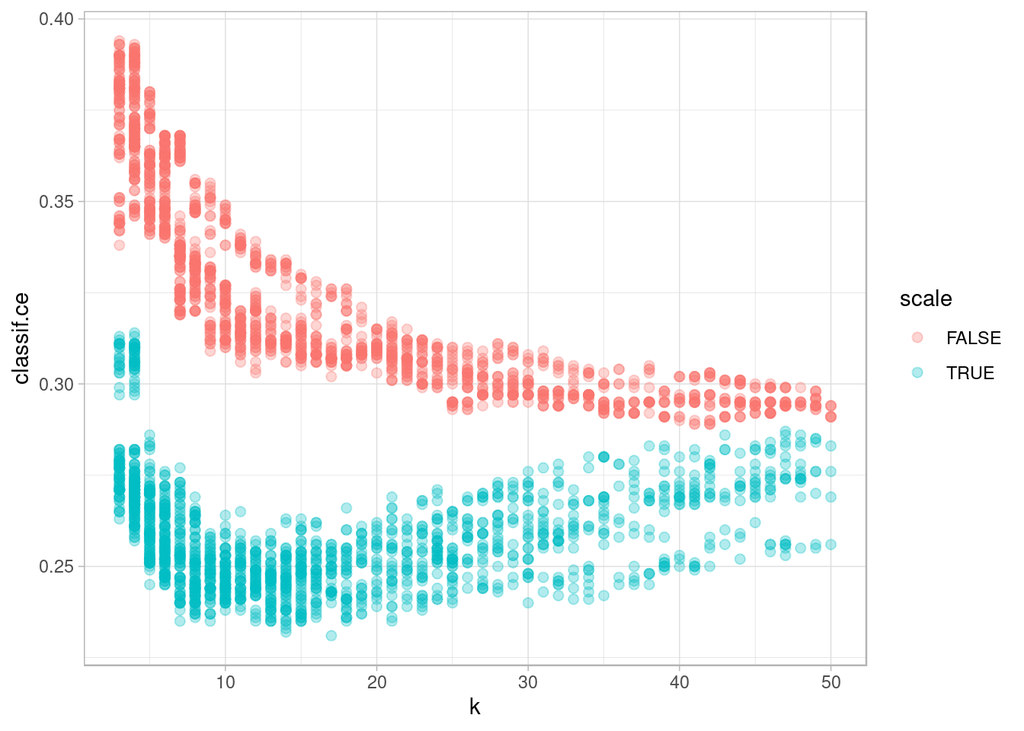

```r
ggplot(perfdata, aes(x = k, y = classif.ce, color = scale)) +
  geom_point(size = 2, alpha = 0.3)
```

- There seems to be a pattern by kernel as well…

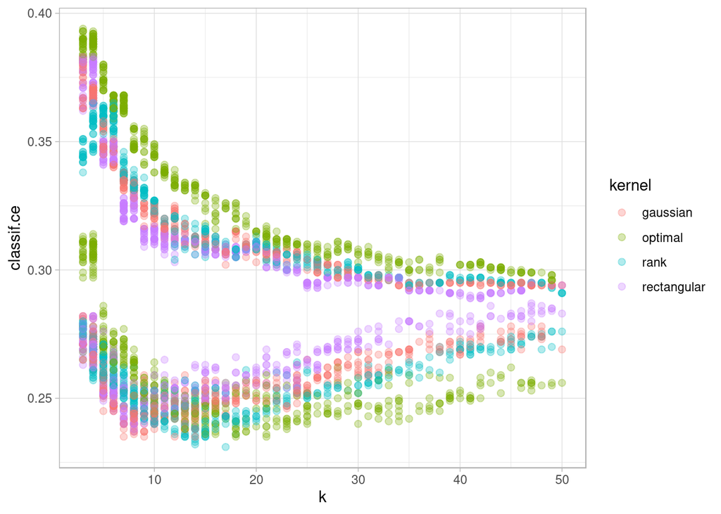

```r
ggplot(perfdata, aes(x = k, y = classif.ce, color = kernel)) +
  geom_point(size = 2, alpha = 0.3)
```

- In fact, if we zoom in to `(5, 30)` x `(0.2, 0.3)` and do loess smoothing we see that different kernels have their optimum at different `k`.

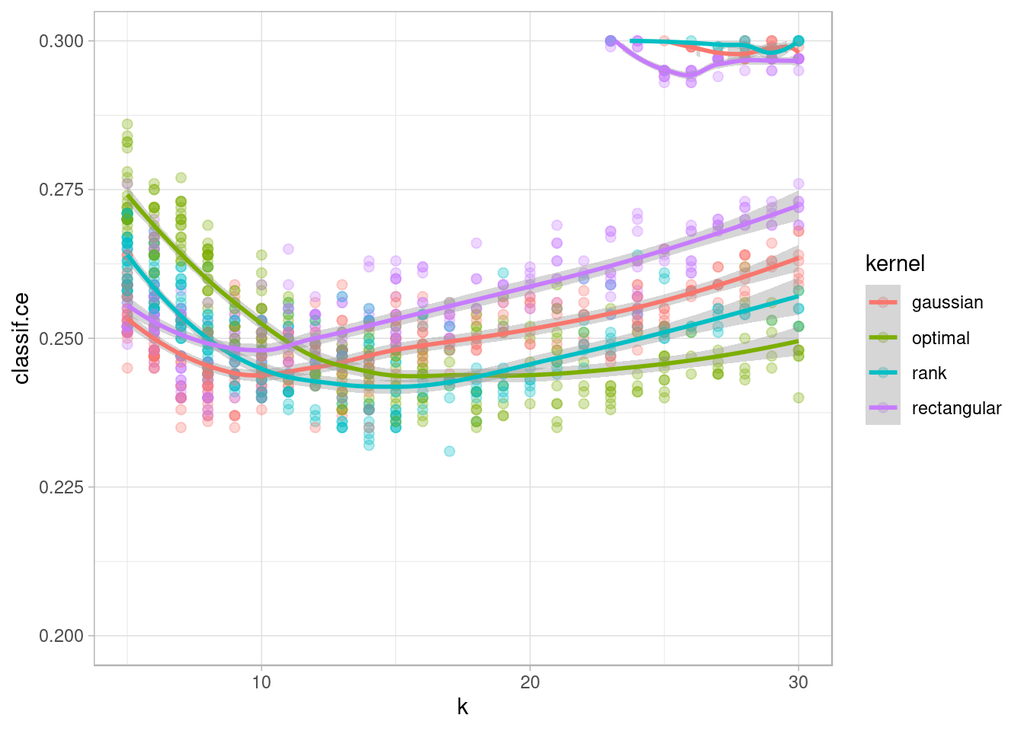

```r
ggplot(perfdata, aes(x = k, y = classif.ce, color = kernel,
  group = interaction(kernel, scale))) +
  geom_point(size = 2, alpha = 0.3) + geom_smooth() +
  xlim(5, 30) + ylim(0.2, 0.3)
```

- What about the `distance` parameter? If we select all results with `k` between 10 and 20 and plot distance and kernel we see an approximate relationship

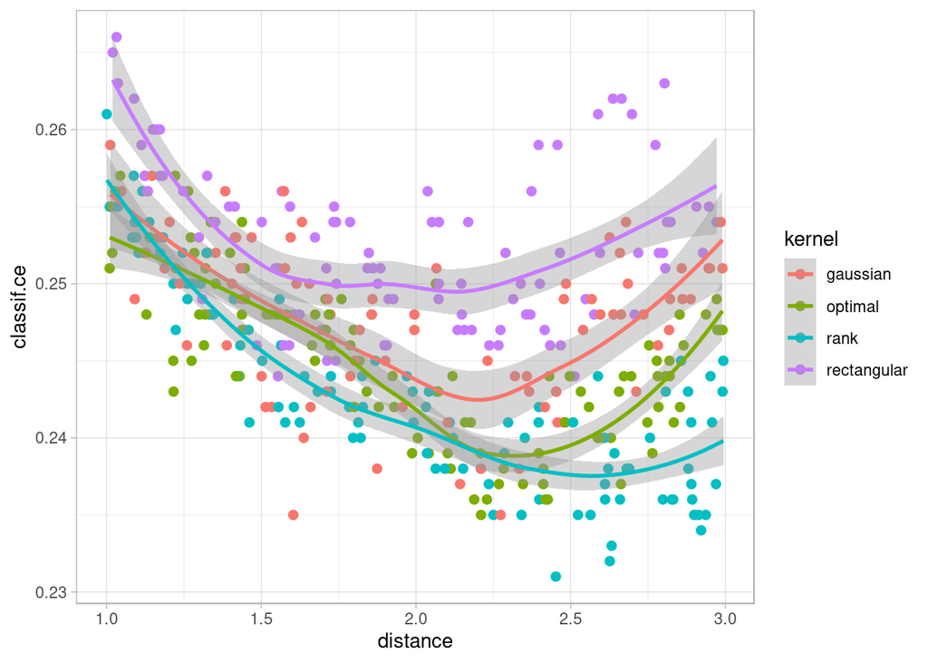

```r
ggplot(perfdata[k > 10 & k < 20 & scale == TRUE],
  aes(x = distance, y = classif.ce, color = kernel)) +
  geom_point(size = 2) + geom_smooth()
```

- Observations: - The `scale` makes a lot of difference - The `distance` seems to make the least difference - Had we done grid search, we would have wasted a lot of evaluations on trying different `distance` values that usually give similar results. This is why random search works well. - An even more intelligent approach would be to observe that `scale = FALSE` performs badly and not try out so many points with that one.

# Tuning Results and Nested Resampling

- Which method works better? If we choose our best model, how well will it perform in the wild?
- Naive comparison:

```r
instance_random$result$perf
```

```
#> classif.ce
#>      0.244
```

```r
instance_grid$result$perf
```

```
#> classif.ce
#>      0.248
```

- Problem: *overtuning*:
  - The more we search, the more our result is likely to just be “lucky” on your training data
  - Different search spaces or search methods may introduce different amounts of randomness, so even the comparison is flawed!
- Solution: Nested Resampling

## Nested Resampling

- Let’s act like our tuning method is actually a `Learner`!
- `$train()` method:
  - Tune hyperparameters on the training data
  - Train a model with optimal hyperparameters on training data
- `$predict()` method: use model trained on training data as model
- This is just the workflow we use when tuning hyperparameters: Find the best parameters and use them for training.
- The `AutoTuner` does exactly this.

```r
grid_auto = AutoTuner$new(
  learner = knn,
  resampling = rsmp("cv", folds = 10),  # we can NOT use fixed resampling here
  measures = msr("classif.ce"),
  tune_ps = searchspace,
  terminator = term("none"),
  tuner = tnr("grid_search")
)
grid_auto$id = "gridsearch"

random_auto = AutoTuner$new(
  learner = knn,
  resampling = rsmp("cv", folds = 10),
  measures = msr("classif.ce"),
  tune_ps = large_searchspace,
  terminator = term("evals", n_evals = 36),
  tuner = tnr("random_search")
)
random_auto$id = "randomsearch"
```

- Let’s benchmark these
- We can also compare this to the random forest, which often performs well without tuning

```r
design = data.table(
  task = list(task),
  learner = list(grid_auto, random_auto, lrn("classif.ranger")),
  resampling = list(cv10_instance)
)
```

- We are running 2 `AutoTuner`s **x** 10 outer resampling folds **x** 36 tuning steps **x** 10 inner resampling folds (plus 10 short folds of `ranger`). This may take a while, having many CPU cores helps.

```r
bmr = benchmark(design)
```

```r
bmr$aggregate()
```

```
#>    nr  resample_result    task_id     learner_id resampling_id iters classif.ce
#> 1:  1 <ResampleResult> new_credit     gridsearch            cv    10      0.259
#> 2:  2 <ResampleResult> new_credit   randomsearch            cv    10      0.242
#> 3:  3 <ResampleResult> new_credit classif.ranger            cv    10      0.247
```

# ROC Analysis

- A bank may have to consider that falsely granting a credit that ends up a default (“false positive”) may be more costly than falsely rejecting a customer who would have paid up (“false negative”).
- `Learners` can predict “probabilities” and the Bank may choose different cutoff values
- What are the tradeoffs between false positive and false negative rates?
- We use `resample()` to generate data about model predictions vs. actual values

```r
pred = resample(task, lrn("classif.ranger", predict_type = "prob"), cv10_instance)$prediction()
```

- The resampling prediction contains true values as well as probability predictions

```r
pred
```

```
#> <PredictionClassif> for 1000 observations:
#>     row_id truth response prob.good  prob.bad
#>         15  good      bad 0.4121127 0.5878873
#>         33  good     good 0.6976475 0.3023525
#>         37  good     good 0.5680500 0.4319500
#> ---
#>        960  good     good 0.6307579 0.3692421
#>        963  good     good 0.8709921 0.1290079
#>        979   bad     good 0.8790214 0.1209786
```

- We can plot the ROC using `mlr3viz`. The curve is a `ggplot` plot, so we can add further details.
- Suppose the bank does not want to get more than a 10% false positive rate

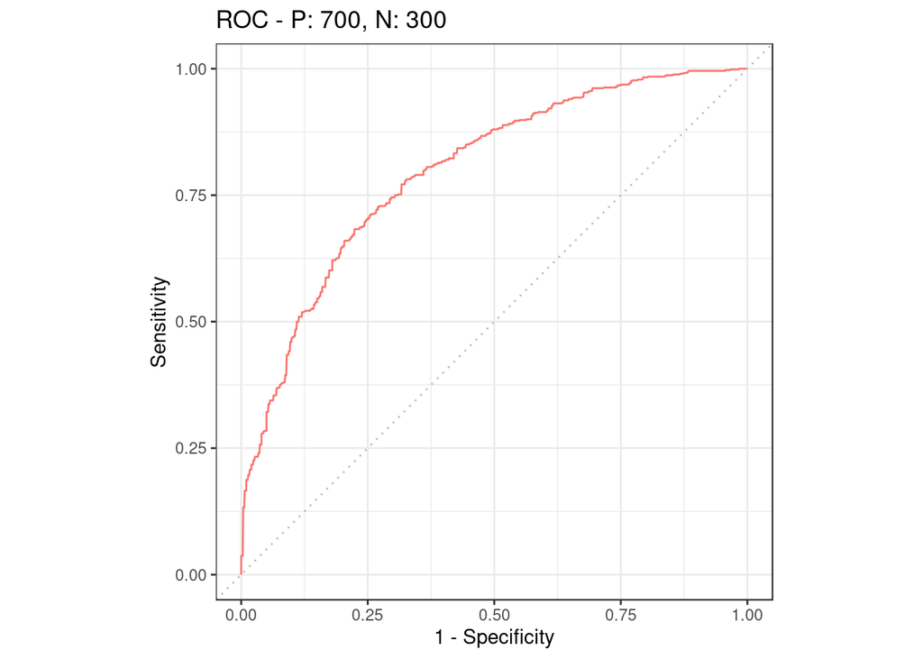

```r
library("mlr3viz")
roc(pred)
```

- What does the naive prediction (decision boundary at 50%) look like?

```r
pred$confusion
```

```
#>         truth
#> response good bad
#>     good  640 176
#>     bad    60 124
```

```r
pred$score(msr("classif.fpr"))
```

```
#> classif.fpr
#>   0.5866667
```

```r
pred$score(msr("classif.fnr"))
```

```
#> classif.fnr
#>  0.08571429
```

- That is a high false positive rate. We could adjust the decision bound and do better.

## Misclassification Cost and Threshold Optimization

- Suppose the outlook is as follows: The bank gains or loses only when it engages with a potential customer, but losses are more severe if the customer defaults. | | Good Customer (truth) | Bad Customer (truth) | | :- | :- | :- | | Good Customer (predicted) | +0.35 | -1.0 | | Bad Customer (predicted) | 0 | 0 |

```r
# note we have "costs" which is negative profit
cost = matrix(c(-0.35, 0, 1, 0), nrow = 2)
dimnames(cost) = list(response = c("good", "bad"), truth = c("good", "bad"))
cost
```

```
#>         truth
#> response  good bad
#>     good -0.35   1
#>     bad   0.00   0
```

- `mlr3` provides us with a “cost measure” that tells us how good our algorithm is doing. The bank is profitable (negative costs).

```r
costmsr = msr("classif.costs", costs = cost)
pred$score(costmsr, task = task)
```

```
#> classif.costs
#>        -0.048
```

- How are different thresholds doing? E.g. being more selective

```r
pred$set_threshold(0.75)
```

```
#> <PredictionClassif> for 1000 observations:
#>     row_id truth response prob.good  prob.bad
#>         15  good      bad 0.4121127 0.5878873
#>         33  good      bad 0.6976475 0.3023525
#>         37  good      bad 0.5680500 0.4319500
#> ---
#>        960  good      bad 0.6307579 0.3692421
#>        963  good     good 0.8709921 0.1290079
#>        979   bad     good 0.8790214 0.1209786
```

```r
pred$score(costmsr, task = task)
```

```
#> classif.costs
#>      -0.09095
```

- This is better. What is the best we can do?

```r
objective = function(thresh) {
  pred$set_threshold(thresh)
  pred$score(costmsr, task = task)
}

opt_result = optimize(objective, interval = c(0, 1))

opt_result
```

```
#> $minimum
#> [1] 0.6914744
#>
#> $objective
#> classif.costs
#>       -0.0978
```

## Bonus Insight

- We note that the line of constant cost has a slope of `1 / .35 * 300 / 700` (from the marginal cost of getting one more false positive vs. true positive, and the number of negative vs. positive people in the test population). The optimum has a TPR and FPR corresponding to a tangent to this line.

```r
slope = 1 / .35 * 300 / 700

pred$set_threshold(opt_result$minimum)
```

```
#> <PredictionClassif> for 1000 observations:
#>     row_id truth response prob.good  prob.bad
#>         15  good      bad 0.4121127 0.5878873
#>         33  good     good 0.6976475 0.3023525
#>         37  good      bad 0.5680500 0.4319500
#> ---
#>        960  good      bad 0.6307579 0.3692421
#>        963  good     good 0.8709921 0.1290079
#>        979   bad     good 0.8790214 0.1209786
```

[figure not shown]

```r
our_point = list(
  x = pred$score(msr("classif.fpr")),
  y = pred$score(msr("classif.tpr"))
)

# increment grey line intercept: increasing cost by 0.01 units shifts the equal
# cost line by 1 / cost_per_TPR.
# cost_per_TPR: (cost gained per true pos indiv) * (fraction of pos individua)
increm = 1 / (.35 * 700 / 1000) / 100
roc(pred) +
  geom_abline(intercept = c(seq(-2, 0, by=increm), seq(0, 2, by = increm)),
  slope = slope, color = "gray", size = 0.5) +
  geom_abline(intercept = c(seq(-2, 0, by=increm*10), seq(0, 2, by=increm*10)),
  slope = slope, color = "gray", size = 1) +
  geom_abline(intercept = our_point$y - slope * our_point$x, slope = slope) +
  geom_point(aes(x = our_point$x, y = our_point$y),
    size = 7, shape = "plus", color = "blue") +
  ggtitle("ROC; Grey lines: equal cost lines in increments of -0.01")
```

# Appendix

## Very quick `paradox` primer

Initialization:

```r
ParamSet$new(list( <PARAMETERS> ))
```

Possible parameter types:

```r
# - logical (values TRUE, FALSE)
ParamLgl$new("parameter_id")
# - factorial (discrete values from a list of 'levels')
ParamFct$new("parameter_id", c("value1", "value2", "value3"))
# - integer (from 'lower' to 'upper' bound)
ParamInt$new("parameter_id", lower = 0, upper = 10)
# - numeric (from 'lower' to 'upper' bound)
# - unfortunately named after the storage type, "double precision floating point"
ParamDbl$new("parameter_id", lower = 0, upper = 10)

# Also possible: "untyped", but we can not tune with this!
ParamUty$new("parameter_id")
```

So an example parameter set with one logical parameter `"flag"` and one integer parameter `"count"`:

```r
ParamSet$new(list(
  ParamLgl$new("flag"),
  ParamInt$new("count", lower = 0, upper = 10)
))
```

```
#> ParamSet:
#>       id    class lower upper      levels     default value
#> 1:  flag ParamLgl    NA    NA  TRUE,FALSE <NoDefault>
#> 2: count ParamInt     0    10             <NoDefault>
```

See the [online vignette](https://mlr3book.mlr-org.com/paradox.html) of `paradox` for a more complete introduction.